# A19.19

$\Delta P$ は $y$ 方向に距離 $d$ 離れた位置でのストリンガー軸荷重の変化に等しい。

我々の問題におけるセルは閉じた構造であるため、任意の点における $q_0$ の値は未知である。図 A19.27 に示すように、ウェブ 1-14 が切断されていると仮定し、その面上での値をゼロとする。したがって、式 (6) は以下のように簡略化される。

$$q_y = - \Sigma \frac{\Delta P}{27.5}$$
—(7)

表 A19.4 の第 1 列から第 5 列は式 (7) の解を示している。第 5 列のせん断流 $q_y$ の値は、図 A19.27 のセル壁にプロットされている。ここで $q_y = q_x = q_z$ であることを考慮されたい。 $q_x$ および $q_z$ の方向を決定する規則については、第 A14 章、第 A14.6 節を参照されたい。

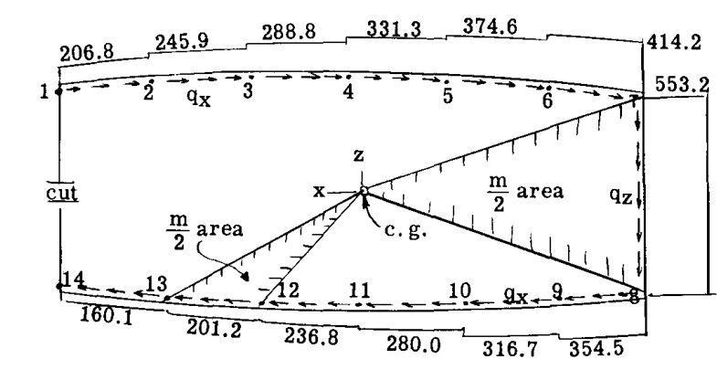

図 A19.27

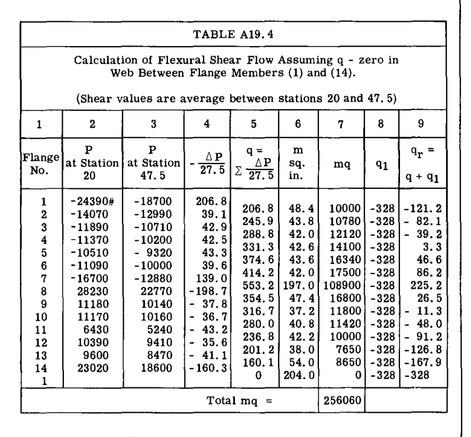

表 A19.4

断面内のすべての力の釣り合いから、 $\Sigma M_y$ はゼロでなければならない。便宜上、断面の重心（c.g.）を通るモーメント $y$ 軸を選択する。任意のシート要素におけるせん断流 $q$ のモーメントは、シート要素の両端と重心を結ぶことによって形成される三角形の面積の 2 倍（2倍面積）に $q$ を乗じたものに等しい。これらの2倍面積は $m$ 値と呼ばれる（図 A19.27 参照）。 表 A19.4 の第 6 列は、プラニメーターを用いて得られたこれらの2倍面積を記録している。第 7 列は、重心まわりの各せん断流のモーメントを示しており、この列の合計は、図 A19.27 の完全なせん断流システム全体の重心まわりのモーメント、すなわち $256060 \text{ in.lb.}$ を与える。

2倍面積（ $m$ ）は、近似的に以下のように求めることができる。

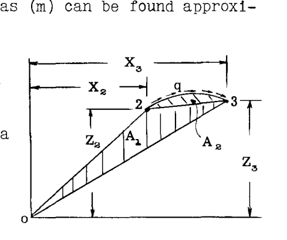

ウェブ2-3

点 O まわりのウェブ (2-3) 上のせん断流 $q$ のモーメントは、面積の 2 倍 $(A_1 + A_2)$ に $q$ を掛けたものに等しい。ほとんどの場合、面積 $A_2$ は無視できる。

簡単な幾何学により、面積は以下のように表される。

$$A_1 = \frac{1}{2} (X_3 Z_2 - X_2 Z_3)$$

したがって、ウェブ (2-3) 上のせん断流 $q$ のモーメントは $q(X_3 Z_2 - X_2 Z_3)$ に等しい。重心断面を基準としたすべてのフランジ位置における $X$ および $Z$ の値は表 A19.2 に与えられているため、曲率が急激な領域を除いて、プラニメーターを使用する必要はない。

## ステーション20の重心まわりの外力モーメント

前述のように、荷重計算グループから、様々なスパン方向ステーションにおけるせん断力とモーメントが提供される。これらの荷重を以下のように仮定する。 $V_z = 12000 \text{ lb.}$ , $V_x = +2700 \text{ lb.}$ , $M_y = -390000 \text{ in.lb.}$ 荷重グループによって使用される基準 $y$ 軸の位置は、ステーション 20 の断面に対して、図 A19.28 の点 O に位置すると仮定する。

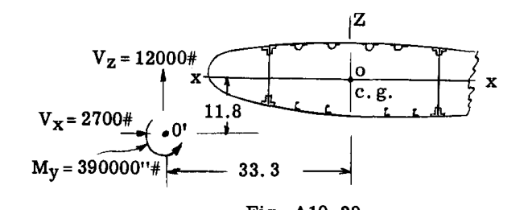

図 A19.28

したがって、重心まわりの外力モーメントは以下のようになる。

$$\Sigma M_{c.g.} = 12000 \times 33.3 - 2700 \times 11.8 - 390000 = -41800 \text{ in.lb.}$$

### フランジ荷重の傾斜によって生じるモーメント

フランジ部材は一般に梁断面に対して直交していないため、フランジ荷重は $Z$ 方向および $X$ 方向の成分を持つ。表 A19.5 の第 4 列および第 7 列は、これらの面内成分の値を示している。ステーション 20 と 47.5 の間の傾き $dx/dy$ は、図 A19.24 から測定して求められる。図 A19.29 は、表 A19.5 で求められたこれらの誘起面内力を示している。

# A19.20 ANALYSIS OF WING STRUCTURES

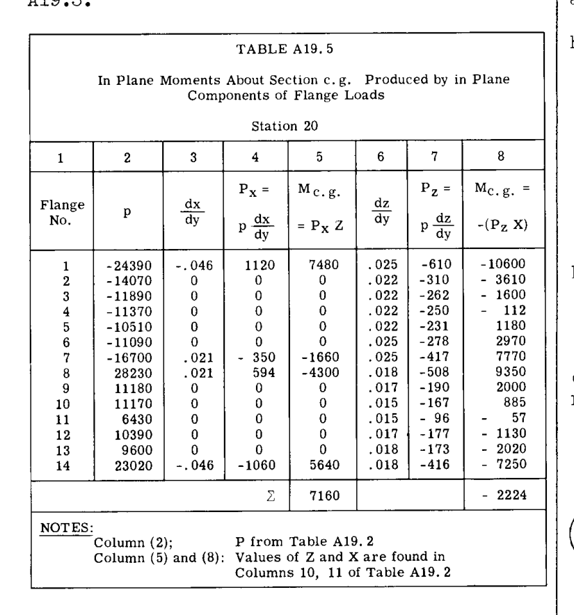

表 A19.5

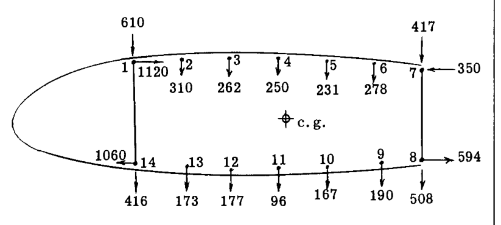

図 A19.29

これらの面内成分の重心断面まわりのモーメントは、表 A19.5 の第 5 列および第 8 列に示されている。一般に、これらのモーメントは大きくない。

### ステーション20における重心まわりの全カの合計モーメント:

フランジによるモーメント = $7160 - 2224 = 4936 \text{ in.lb.}$ (表 A19.5 参照)

仮定した静的せん断流によるモーメント = $256060 \text{ in.lb.}$ (表 A19.4 参照)

外力荷重によるモーメント = $41800 \text{ in.lb.}$

したがって、合計不釣り合いモーメントは以下のようになる。

$$4936 + 256060 + 41800 = 302796 \text{ in.lb.}$$

平衡状態を保つためには、これを一定のせん断流 $q_1$ によって打ち消さなければならない。

したがって、

$$q_1 = -\frac{M}{2A} = -\frac{302796}{2 \times 461.5} = -328 \text{ lb./in.}$$

(注: $461.5 = \text{セルの総面積}$ )

せん断流 $q_1$ は表 A19.4 の第 8 列にリストされている。

したがって、任意の点における最終または合成せん断流 $q_r$ は以下に等しくなる。

$$q_r = q + q_1$$

計算結果は表 A19.4 の第 9 列に示されている。図 A19.30 はこの結果を視覚的に示している。

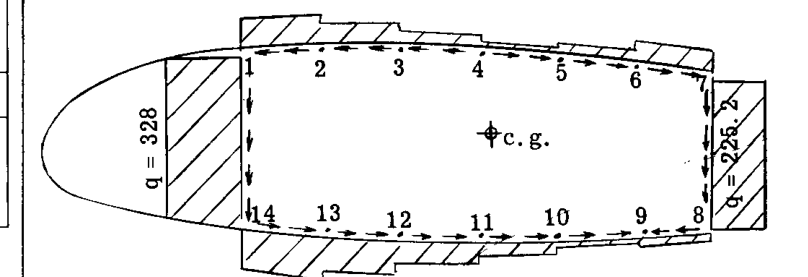

図 A19.30

せん断流が決定されれば、任意のパネルにおけるせん断応力は $q/t$ となる。シートのせん断強度およびせん断と引張の複合応力下での強度をチェックするには、相互作用関係が必要となる。複合応力下におけるシートパネルの強度設計については、第 C5 章で詳しく説明されている。

## A19.14 2セルマルチストリンガーテーパーカンチレバー翼の曲げおよびせん断応力解析

2セル構造の梁も、翼の構造設計において一般的である。曲げおよびねじりを受ける2セル構造は、各セル内の任意の点におけるせん断流が未知であるため、2次の静定不定構造である。しかし、セル間の連続性により、各セルのねじれ角は等しくなければならず、これにより、単一セル解析と比較して2セル梁を解くために必要な追加の式が得られる。

### 例題

同様のタイプの計算の繰り返しを避けるため、前述の単一セル問題と同じ構造について、前縁セルも有効である（2セル構造を形成する）と仮定して、曲げ応力とせん断応力を決定する。前縁にスパン方向のストリンガーが存在しないため、圧縮側の外板はほとんど有効に機能しない。引張側では、前縁外板は曲げ軸荷重に抵抗するのに有効であり、したがって慣性モーメントは例題 1 で得られたものとはわずかに異なる。この問題は方程式の使用法を説明することのみを目的としているため、曲げ曲げ応力の計算においては前縁外板を無視する。この仮定の下では、ステーション 20 および 47.5 における曲げ応力とフランジ荷重は、前の問題と同じである（表 A19.2 および A19.3 の第 12 列と第 13 列の値を参照）。

### せん断流の計算:

静的せん断流を計算するために、図 A19.31 に示すように、各セルは 1 箇所で切断されていると仮定し、したがって、点 (a) および (b) におけるせん断流はゼロである。

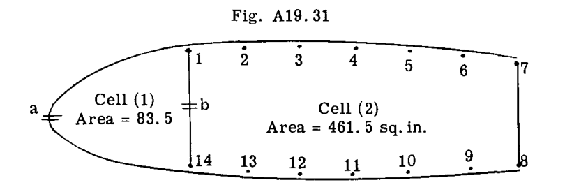

図 A19.31

表 A19.6（第 5 列）は、これらの仮定の下での静的せん断流の値を示している。

# A19.21

表 A19.6 の最初の 7 列は、セル (1) にストリンガーが追加されておらず、セル (1) のせん断流 $q$ がゼロと仮定されているため、表 A19.4 と同一である。

各セルのねじれ角を同じにし、すべてのねじりモーメントの和をゼロにするためには、セル (1) 内の $q_1$ とセル (2) 内の $q_2$ という2つの未知の一定せん断流が必要となる。したがって、以下の2つの式が立てられる。

$$\theta_1 = \theta_2$$
—(8)

$$\Sigma M_{c.g.} = 0$$
—(9)

セルの単位長さあたりのねじれ角 $\theta$ は以下に等しい。

$$\theta = \frac{1}{2AG} \sum \frac{qL}{t}$$
—(10)

剛性率 $G$ は一定であると仮定し、省略する。

セル (1) を考える（表 A19.6 の第 10 列および第 11 列を参照）：

$$\text{セル (1) の面積} = 83.5 \text{ sq. in.}$$

$$\theta_1 = \frac{1}{2A_1} \left[ \sum q \frac{L}{t} + \sum q_1 \frac{L}{t} + \sum q_2 \frac{L}{t} \right]$$

$$\theta_1 = \frac{1}{2 \times 83.5} [0 + 1278 q_1 - 230 q_2]$$

$$\theta_1 = 7.65 q_1 - 1.378 q_2$$
—(a)

セル (2) について：

$$\text{セル (2) の面積} = 461.5 \text{ sq. in.}$$

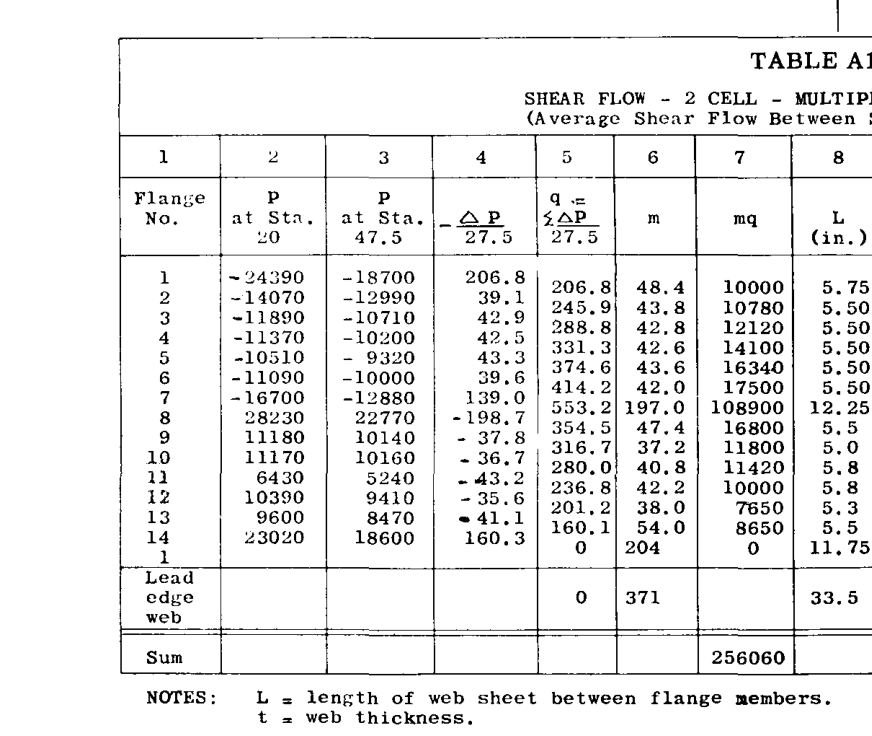

表 A19.6

# A19.22 ANALYSIS OF WING STRUCTURES

$$\theta_2 = \frac{1}{2 \times 461.5} [733050 - 230 q_1 + 2469 q_2]$$

$$\theta_2 = 794 - .2495 q_1 + 2.678 q_2$$
—(b)

連続性の条件から $\theta_1$ は $\theta_2$ に等しくなければならないため、式 (a) と (b) を等置すると以下のようになる。

$$7.899 q_1 - 4.056 q_2 - 794 = 0$$
—(c)

平衡状態を保つためには、重心断面まわりのすべてのモーメントの和がゼロでなければならない。

$$\Sigma M_{c.g.} = 0$$

外力によるモーメントは、前の問題と同様に以下の通りである。

$$M_{\text{external forces}} = 41800 \text{ in.lb.}$$

フランジ軸荷重の面内成分による誘起モーメントも、前の問題と同様である（表 A19.5 参照）。

$$M_{\text{due to flange loads}} = 4936 \text{ in.lb.}$$

表 A19.6 の第 7 列からの静的せん断流によるねじりモーメントは $256060 \text{ in.lb.}$ に等しい。未知の一定せん断流 $q_1$ および $q_2$ によるトルクは、各セルの囲まれた面積の 2 倍にそのセル内のせん断流を掛けたものの和に等しい。すなわち、

$$M_{\text{due to } q_1 \text{ and } q_2} = 2 \times 83.5 q_1 + 2 \times 461.6 q_2 = 167 q_1 + 923 q_2$$

したがって、

$$\Sigma M_{c.g.} = 167 q_1 + 923 q_2 + 302796 = 0$$
—(d)

式 (c) と (d) を解くことにより、以下が得られる。

$$q_1 = -62.8 \text{ lb./in.}, \quad q_2 = -317 \text{ lb./in.}$$

これらの値は、表 A19.6 の第 12 列および第 13 列に示されている。任意のシートパネルにおける最終的な合成せん断流 $q_r$ は、 $q + q_1 + q_2$ の和に等しくなる。結果は表 A19.6 の第 14 列に示されている。図 A19.32 は、プロットされたせん断流の分布を示している。この図と図 A19.30 を比較すると、前の問題の単一セルに前縁セルを追加した効果がよくわかる。

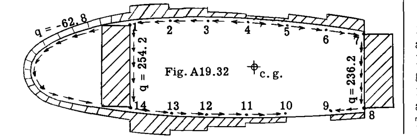

図 A19.32

## A19.15 厚板外板の曲げ強度 - 翼断面

図 A19.3 の i および k は、超音速航空機の翼形の近似形状を示している。このような翼形は比較的厚さ比が低く、また超音速軍用機は比較的高い翼荷重を持つため、翼の曲げモーメントに効率的に抵抗するためには厚板外板を採用する必要がある。このような構造の極限圧縮応力は、かなり均一にすることができ、材料の降伏点をかなり上回る応力で発生させることができる。構造は破損することなく設計荷重を支持しなければならないため、様々な荷重条件に対して安全余裕を与えるためには、このような翼断面の極限曲げ抵抗を計算できる必要がある。

弾性応力範囲を超える応力で破損する梁断面の極限曲げ抵抗の問題は、第 A13.10 節および第 A13 章の例題 7 で扱われており、次の例題に進む前に再度学習しておく必要がある。

## A19.16 例題

第 A13.10 節の手順を説明するために、図 A19.34 に示すような厚板外板翼断面の一部を考える。

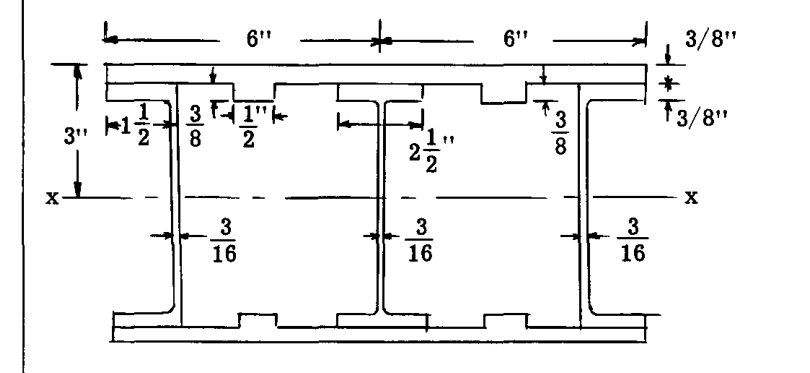

図 A19.34

簡単にするために、断面は $x-x$ 軸に対して対称に描かれている。材料はアルミニウム合金である。この問題では、引張側と圧縮側の両方で材料の応力-ひずみ曲線が同一であると仮定する。設計曲げモーメント $M_x = 1850000 \text{ in.lb.}$ が作用するときの、この梁断面の安全余裕を決定することが課題である。

### 解法:

梁の公式 $\sigma_b = M_x z / I_x$ を使用することが望ましいため、非線形応力-ひずみ関係を補正するために修正された梁断面を得る必要がある。最大圧縮応力は $50000 \text{ psi}$ と仮定する。

# A19.23

図 A19.35a の曲線 (A) は、 $0$ から $50000 \text{ psi}$ までのアルミニウム合金材料の圧縮応力-ひずみ図の一部である。

$x-x$ 軸に対する対称性から、梁断面の半分のみを考慮すればよい。梁断面の上半分を、それぞれ厚さ $3/8 \text{ インチ}$ の水平な細条（ストリップ）に分割する。これらの水平細条に沿った各梁部分は、図 A19.35b において (1) から (8) とラベルされた領域を形成するように配置することができる。弾性応力状態および非弾性応力状態のいずれにおいても、平面断面は曲げ後も平面を維持するため、図 c は梁断面のひずみ分布を示している。

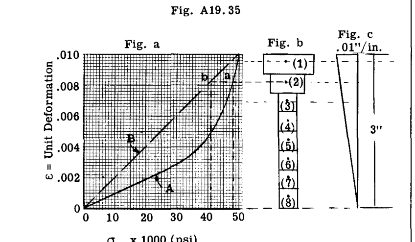

図 A19.35

表 A19.7 は、線形梁公式で使用するための、断面の修正慣性モーメントを得るための計算を示している。

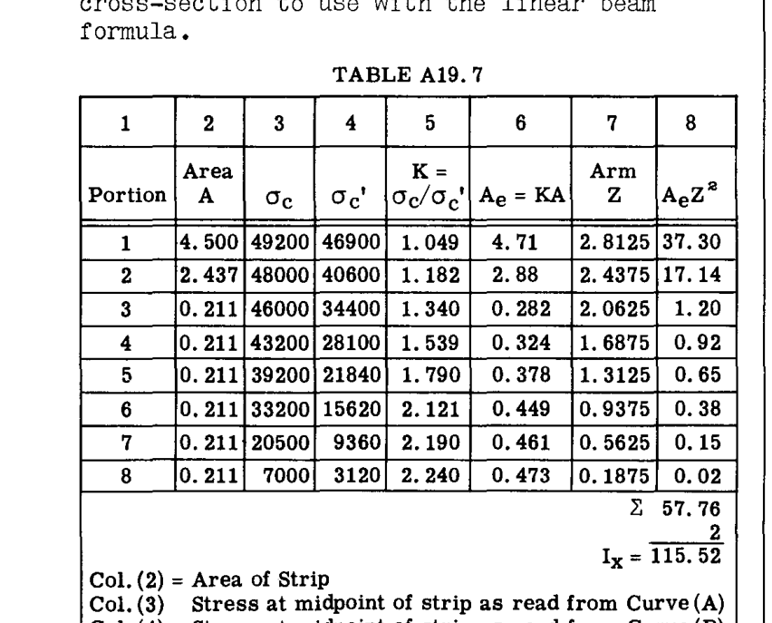

表 A19.7

表 A19.7 の第 3 列の値は、梁が最大曲げモーメントに抵抗しているときの、細条領域の中点における真の圧縮応力を示している。第 4 列の値は、曲げ応力が線形であり、中立軸でのゼロから梁断面の端部での $50000 \text{ psi}$ まで変化する場合の、細条領域の中点における圧縮応力を示している（図 A19.35a の曲線 B）。

説明のために、図 A19.35b の細条領域番号 (2) を考える。この細条の中点から、曲線 A および B とそれぞれ交点 (a) および (b) で交わるまで、水平な破線を引く。これらの交点から下方に投影すると、それぞれ $48000 \text{ psi}$ および $40600 \text{ psi}$ の値を読み取ることができる。

線形梁公式を使用すると、細条 (2) における応力強度は $40600$ となるが、実際には $48000$ である。この2つの比を記号 $K$ で表す。したがって、非線形応力と等しくなるように線形応力を修正するために、真の細条面積を係数 $K$ 倍して、第 6 列の結果を得る。

修正された慣性モーメント（第 8 列）は $I_x = 115.52$ に等しい。

設計曲げモーメントは $1850000 \text{ in.lb.}$ であった。

細条 (1) の中点における点を考える。

$$Z = 2.8125 \text{ inches}$$

$$\sigma_b = M_x Z / I_x = (1850000 \times 2.8125) / 115.52 = 45100 \text{ psi.}$$

この応力は、修正された細条面積に基づいている。したがって、細条 (1) における真の応力 $\sigma_{b(t)}$ は以下のようになる。

$$K \sigma_b = 1.049 \times 45100 = 47400 \text{ psi.}$$

破壊時の許容応力は、表 A19.7 の第 3 列から $49200$ である。したがって、安全余裕（M.S.）は以下のようになる。

$$\text{M.S.} = (49200 / 47400) - 1 = .04 \quad (4\%)$$

梁断面の他の点における安全余裕も同様に $4\%$ となる。たとえば、細条 (3) の中点では、 $Z = 2.0625$ , $K = 1.34$ であり、したがって以下のようになる。

$$\sigma_{c(t)} = [(1850000 \times 2.0625) / 115.52] \times 1.34 = 44400 \text{ psi.}$$

したがって、安全余裕は以下の通りである。

$$\text{M.S.} = (46000 / 44400) - 1 = .04$$

細条面積を修正せずに慣性モーメントを計算すると $I_x = 104.42$ となり、細条 (1) の中点における応力は以下のように計算される。

$$\sigma_b = (1850000 \times 2.8125) / 104.42 = 49900 \text{ psi.}$$

線形応力変化に対する許容応力は、表の第 4 列から $46900$ となる。したがって、安全余裕は以下のようになる。

# A19.24 ANALYSIS OF WING STRUCTURES

$$(46900 / 49900) - 1 = -.06$$

したがって、弾性理論を適用した場合、真の応力-ひずみ関係、すなわち非線形関係を使用した場合よりも、強度が $10\%$ 低く評価され、負の安全余裕が与えられることになる。

同じ梁断面について $Z$ 軸まわりの曲げを考えた場合、曲線 A と B の乖離が大きい領域でより多くの梁面積が機能するため、差は $10\%$ よりも大幅に大きくなる。

## A19.17 実用的な翼断面への適用

実用的な翼断面には、以下の事実が含まれる。 1. 断面が非対称である。 2. 異なる飛行条件において、外力荷重の面が方向を変える。 3. 非弾性領域において、引張と圧縮で材料の応力-ひずみ曲線が異なる。

多くの条件下で臨界安全余裕を決定する必要があるため、 $M_x$ と $M_z$ の曲げモーメントを組み合わせた相互作用曲線を作成することが便利である。この相互作用曲線は以下のようにして得られる。

1. 中立軸方向とその位置を選択する。
2. 平面断面が曲げ後も平面を維持すると仮定し、最大ひずみを圧縮フランジの破壊ひずみとして、応力-ひずみ曲線から軸方向応力を決定し、次に断面の各要素における内部荷重を求める。中立軸の仮定位置の妥当性は、断面上の全圧縮力が全引張力と等しくなることでチェックされる。不一致がある場合は、中立軸を平行に移動して同様の計算を繰り返し、チェックを満たす位置を決定する。
3. 中立軸まわりの内部抵抗モーメント、および中立軸に直交する軸まわりのモーメントを求める。これらのモーメントを $x$ 軸および $z$ 軸まわりのモーメント、すなわち $M_x$ および $M_z$ に分解する。これらの $M_x$ と $M_z$ の値の組み合わせが、翼を曲げ破壊させる限界値となる。
4. 他の中立軸方向についてステップ 1、2、3 を繰り返し、曲げ破壊を引き起こす $M_x$ と $M_z$ の追加の組み合わせを得る。これにより、 $M_x$ と $M_z$ の相互作用曲線が得られ、任意の設計条件に対する安全余裕を容易に求めることができるようになる。

## A19.18 せん断遅れの影響

梁の理論では、平面断面は曲げ後も平面を維持するという仮定がなされている。外板とストリンガーからなるパネルを有する梁において、この仮定は外板パネルが無限のせん断剛性を持つことを意味するが、実際にはせん断応力がせん断ひずみを生じさせるため、これは正しくない。外板パネルのせん断ひずみの影響により、一部のストリンガーは梁理論によって計算される軸荷重よりも少ない荷重にしか抵抗できなくなる。ストリンガーのこの効果的な機能の低下は、一部のストリンガーが、平面断面が平面を維持する場合に取るべき位置から遅れる傾向があるため、「せん断遅れ（シアラグ）」効果と呼ばれる。

一般に、外板-ストリンガー構造におけるせん断遅れの影響は、以下のような状況を除いてそれほど大きくない。

1. 1つ以上のストリンガーが不連続となるカットアウト（開口部）。
2. 集中外力の作用点における急激な変化。
3. ストリンガー断面積の急激な変化。

外板-ストリンガー構造における変形と応力を解くにあたり、せん断応力によるひずみが考慮された。これらの厳密な方法においても、特定の外板パネルにわたってせん断応力が一定であると仮定したり、様々な座屈状態における外板パネルの剛性率を見積もるなどの簡略化が必要である。通常の翼におけるストリンガーと外板パネルの数は非常に多く、構造は高次の静定不定となり、解法には高速コンピューターの使用が必要となる。そのような解析を行う前に、各構造部品のサイズと厚さを知る必要があるため、厳密な弾性解析で使用する正確な初期サイズを得るために、迅速な簡易応力解析手法が望まれる。

せん断遅れ問題を最も単純な状態で説明するために、図 A19.36 の 3 本のストリンガーを持つ外板パネルユニットを考える。3 本のストリンガーは端部 B で頑丈に支持されており、等しい荷重 $P$ が点 (A) で 2 本の端部ストリンガー (1) に作用している。中央のストリンガー (2) は点 (A) において軸荷重を持たないが、端部 B に近づくにつれて、外板パネルはせん断応力によって荷重 $P$ の一部を中央のストリンガーに伝達する。支持点 B においては、端部ストリンガーから中央ストリンガーへの荷重伝達により、3 本のストリンガーすべての荷重がほぼ等しく、すなわち $2P/3$ に等しくなる。

# A19.25

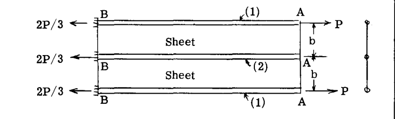

図 A19.36

中央ストリンガーの理論上の荷重は第 A7 章および第 A8 章の方法で計算でき、結果は図 A19.37 の実線のようになる。解法を簡単にするために、中央ストリンガーの荷重分布が図 A19.37 の破線のように変化すると仮定することが一般的である。これは、距離 $3b$ の間に、荷重 $2P$ が 3 本のストリンガー間で均等化されることを示している。

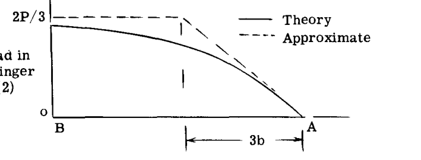

図 A19.37

## A19.19 カットアウトを持つ翼へのせん断遅れ近似の適用

図 A19.38 は、表面にカットアウトを含むマルチストリンガー翼の上面を示している。ストリンガー (5)、(6) および (7) は、カットアウト領域を通じて不連続でなければならない。

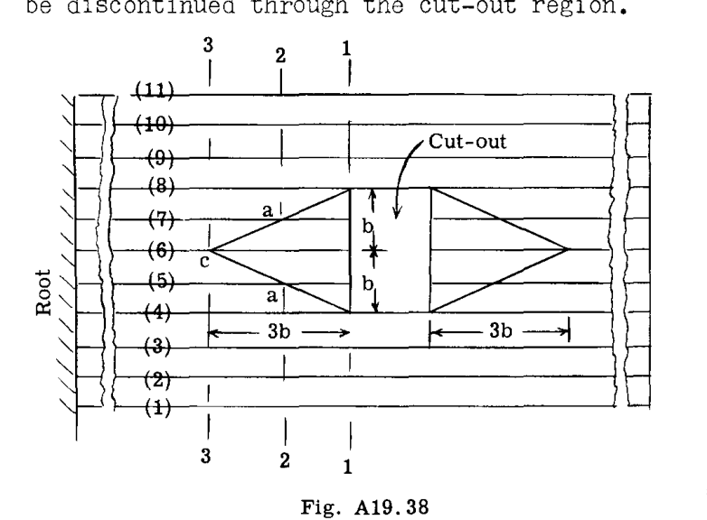

図 A19.38

これら 3 本の不連続ストリンガーの有効性は、図中の三角形によって与えられると仮定する。梁断面 1-1 において、これらのストリンガーはゼロ端部荷重を持つ。ストリンガー荷重は、高さが $3b$ であるこの三角形の辺と交差するときに、完全な有効性まで線形に増加すると仮定される。梁断面 2-2 において、ストリンガー (5) および (7) は断面 2-2 の点 (a) で三角形と交差するため、有効になっている。断面 3-3 の点 (c) において、ストリンガー (6) は完全に有効になる。

実用的な翼の問題においてせん断遅れの影響を処理するために、せん断遅れの影響を考慮するために、表 A19.1 の列 (3) と (4) の間にもう一つの列が挿入される。我々が $R$ と呼ぶせん断遅れ有効係数は、図 A19.38 に示されているような三角形から得られる有効性に等しくなる。

たとえば、図 A19.38 の梁断面 1-1 におけるせん断遅れ係数 $R$ は、ストリンガー (5)、(6) および (7) に対してはゼロであり、他のすべてのストリンガーに対しては 1 となる。断面 2-2 において、ストリンガー (5) および (7) は点 (a) で完全に有効であるため、係数 $R = 1.0$ となる。ストリンガー (6) は、断面 1-1 から点 (c) までの距離の半分である断面 2-2 に位置するため、その有効性は $50\%$ であり、したがってストリンガー (6) に対しては $R = 0.5$ となる。断面 3-3 において、ストリンガー (6) は完全に有効になり、したがってすべてのストリンガーに対して $R = 1.0$ となる。表 A19.1 の第 4 列における最終的な修正ストリンガー面積（ $A$ ）は、真のストリンガー面積に、その有効外板面積に係数 $KR$ を乗じたものを加えたものに等しくなる。この点からの手順は、前に説明したものと同様である。このようにして、せん断遅れの近似は、ストリンガー面積を修正することによって非常に容易に処理することができる。これらの修正されたストリンガー面積を使用することにより、ストリンガー内の真の全荷重が得られる。真の応力は、修正された面積ではなく、これらの荷重を真のストリンガー面積で除したものに等しくなる。

## A19.20 大きな集中荷重が作用する梁領域における近似せん断遅れの影響

翼および胴体構造は、発電装置の反力や着陸装置の反力などの大きな集中力に抵抗することがしばしば要求される。説明のために、図 A19.39 は着陸時の垂直荷重を示す。翼は 7 本のストリンガーを持つボックス梁である。

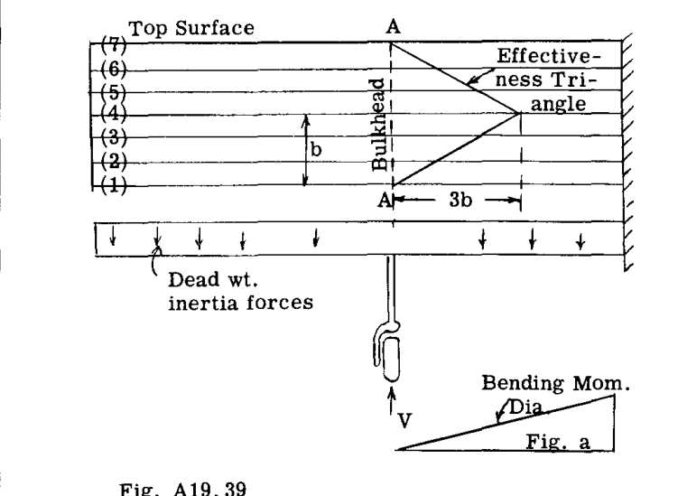

図 A19.39

# A19.26 ANALYSIS OF WING STRUCTURES

図 (a) は、着陸装置の反力のみによる曲げモーメント図を示している。この曲げモーメントに対する内部抵抗は、外板パネル内のせん断ひずみ、すなわちせん断遅れ効果と呼ばれるもののために、断面 A-A に隣接する梁断面において均一にはなり得ない。このストリンガーの有効性を近似するために、長さ $3b$ のせん断遅れ三角形が仮定され、カットアウトに関する前述の記事で説明したものと同じ手順が、軸方向応力を求める際に使用される。翼上の分布力（空気荷重や自重慣性荷重など）による曲げモーメントは、せん断遅れの考慮には含まれず、構造上の集中点に作用し、梁に分配されなければならない力のみが考慮されることを理解されたい。着陸装置や発電装置への横方向荷重は、図 A19.39 のようなせん断力に加えて、局所的な偶力と軸方向力を発生させる。この偶力および軸方向力に対する抵抗も、同様に図 A19.39 の有効性三角形に基づいている。

## A19.21 ストリンガー面積の急激な変化に対するせん断遅れ影響の近似

あるサイズのストリンガーがより小さなサイズのストリンガーにスプライス（結合）されることがよくあり、これによりストリンガー面積の急激な変化による不連続性が生じる。

図 A19.40 は、典型的な外板-ストリンガー翼におけるストリンガーの配置を示している。ストリンガー B は示されている点で結合されている。ストリンガー断面積 $A_2$ は、断面積の小さいストリンガー $A_1$ に結合されることによって急激に減少する。

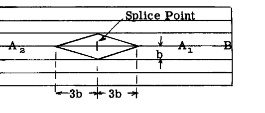

図 A19.40

せん断遅れの影響を近似するために、結合点におけるストリンガー B の面積を、両側の平均面積、すなわち $(A_1 + A_2)/2$ であると仮定する。この平均面積は、結合点から距離 $3b$ の位置で $A_2$ および $A_1$ にテーパーしていると仮定される。したがって、せん断遅れ有効係数 $R$ は、より小さいストリンガー $A_1$ に向かう側では 1.0 より大きくなり、より大きいストリンガー $A_2$ に向かう側では 1.0 より小さくなる（結合点に対して平均面積が使用されたため）。

## A19.22 問題

1. 図 A19.41 は、片持ち式の 3 ストリンガー単一セル翼を示している。これは、 $z$ 方向に上向きに作用する平均強度 $2 \text{ lb./in.}^2$ の分布空気荷重、および $x$ 方向に後方に作用する平均強度 $0.25 \text{ lb./in.}^2$ の分布空気荷重を受けている。 $z$ 方向の力の圧力中心は前縁から $25\%$ のコード線上であり、 $x$ 方向の空気荷重に対してはスパ AB の中高位置にある。3 本のストリンガー A、B、C が外力曲げモーメントに対する全抵抗を負担すると仮定する。翼端から $50"$ 、 $100"$ および $150"$ に位置する翼ステーションにおけるストリンガー A、B、C の軸荷重、およびセル (1) の 3 枚の外板パネルにおけるせん断流を求めよ。セル (1) の後方の構造は、空気荷重を前方のセル (1) に伝達するのみであり、翼のねじりや曲げには抵抗しないものとする。

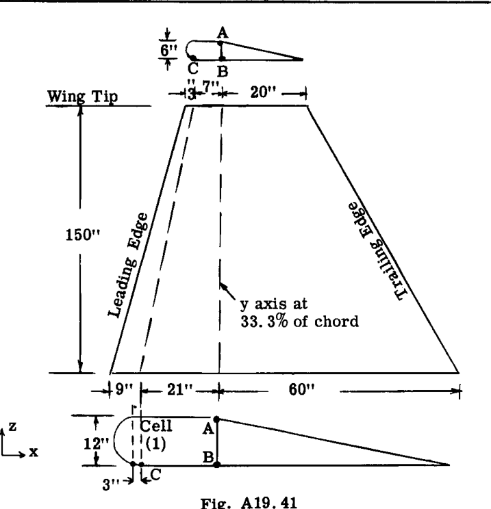

図 A19.41

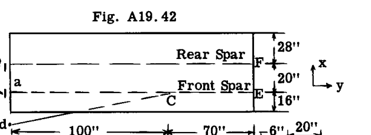

図 A19.42

2. 図 A19.42 は、1 本の外方支持ストラットを持つ単葉翼を示している。翼は、点 (a) および (b) における単一のピンによって胴体に固定されている。(b) におけるフィッティングは抗力反力を受け持つように設計されている。空気荷重は $w_z = 40 \text{ lb./in.}$ であり、圧力中心は前縁からコードの $30\%$ の位置にあり、上向きに作用している。 $w_x = 5 \text{ lb./in.}$ は後方に作用し、翼の中高位置にある。点 (a)、(b) および (d) における反力を求めよ。前部および後部スパの軸荷重を求めよ。前部スパの主要曲げモーメントを求めよ。ウェブおよび壁のせん断流を求めよ。前部スパより前方および後部スパより後方の構造は無視する。

# A19.27

3. 図 A19.43 は、単一セル・マルチストリンガー片持ち翼の一部を示している。外力空気荷重は以下の通りである。

$w_z = 100 \text{ lb./in.}$ 上向きに作用し、その圧力中心はストリンガー (8) と一致する $y$ 軸に沿っている。

$w_x = 6 \text{ lb./in.}$ 後方に作用し、翼の中高位置にある。

表 A は、ステーション 0 および 150 におけるストリンガー面積を示している。ストリンガー面積は、これら 2 つのステーション間で線形に変化するものと仮定する。圧縮ストリンガーに対しては、有効外板として $30t$ を使用せよ。

ステーション 150 および 130 におけるストリンガーの軸荷重を求め、ステーション 150 におけるせん断流システムを決定せよ。

4. 問題 (3) と同様であるが、ストリンガー (3) と (8) を接続する厚さ $.04$ の内部ウェブを追加せよ。
5. 問題 (4) と同様であるが、前部スパの高さの半分に等しい半径を持つ前縁セルを追加せよ。外板の厚さは $.04 \text{ インチ}$ とせよ。

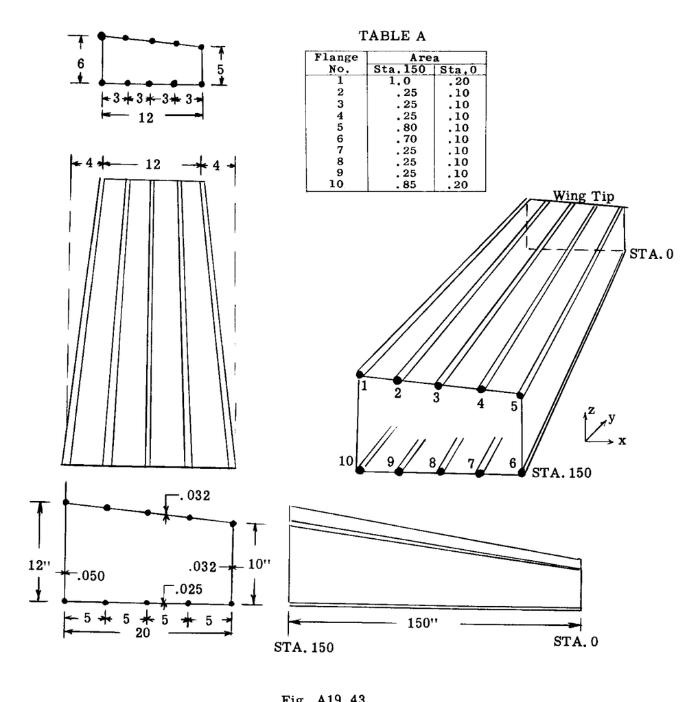

図 A19.43